# Análisis del Dataset *Parkinson Replicated Acoustic Features*

Elena Barro León, Raúl Bonillo Pulido y Paula Merino Purificacion

2025-12-17

[figure not shown]

[figure not shown]

## Introducción

### 1.1 El Parkinson

La **Enfermedad de Parkinson (EP)** es el segundo trastorno neurodegenerativo más común, afectando significativamente a la población mayor de 65 años en Europa. [^1]

Ante la necesidad de métodos diagnósticos complementarios, las grabaciones de voz se han postulado como un biomarcador potencial no invasivo y de bajo coste. Esto se debe a que la EP provoca disfonía, que se caracteriza por inestabilidad del tono y el volumen.[^2]

### 1.2 Los datos

|  | ID | Recording | Status | Gender | Jitter_rel | Jitter_abs | Jitter_RAP | Jitter_PPQ | Shim_loc | Shim_dB | Shim_APQ3 | Shim_APQ5 | Shi_APQ11 | HNR05 | HNR15 | HNR25 | HNR35 | HNR38 | RPDE | DFA | PPE | GNE | MFCC0 | MFCC1 | MFCC2 | MFCC3 | MFCC4 | MFCC5 | MFCC6 | … |
| --- | --- | --- | --- | --- | --- | --- | --- | --- | --- | --- | --- | --- | --- | --- | --- | --- | --- | --- | --- | --- | --- | --- | --- | --- | --- | --- | --- | --- | --- | --- |
| 1 | CONT-01 | 1 | 0 | 1 | 0.25546 | 1.4581e-05 | 0.001467 | 0.0016734 | 0.030256 | 0.26313 | 0.017463 | 0.01966 | 0.021882 | 5.943000000000001 | 6.073 | 7.188 | 7.762 | 7.753 | 0.250432662 | 0.599346197 | 0.005396624 | 0.900403826 | 1.319 | 1.336 | 1.302 | 1.329 | 1.284 | 1.209 | 1.239 | … |
| 2 | CONT-01 | 2 | 0 | 1 | 0.36964 | 2.1662e-05 | 0.0019317 | 0.0022446 | 0.023146 | 0.20217 | 0.01301 | 0.014097 | 0.016828 | 5.983000000000001 | 6.265 | 7.437 | 7.998 | 8.026 | 0.271444855 | 0.581242444 | 0.075617004 | 0.887041519 | 1.215 | 1.221 | 1.265 | 1.187 | 1.256 | 1.246 | 1.283 | … |
| 3 | CONT-01 | 3 | 0 | 1 | 0.23514 | 1.3109e-05 | 0.0013527 | 0.0015465 | 0.019338 | 0.1671 | 0.011049 | 0.012683 | 0.013038 | 5.729 | 6.185 | 7.366 | 7.893 | 7.903 | 0.20353077 | 0.600759218 | 0.005282874 | 0.889399386 | 1.426 | 1.22 | 1.344 | 1.346 | 1.339 | 1.334 | 1.391 | … |
| 4 | CONT-02 | 1 | 0 | 0 | 0.2932 | 1.7331e-05 | 0.0011048 | 0.0014443 | 0.024716 | 0.20892 | 0.014525 | 0.015696 | 0.01833 | 621.7950000000001 | 6.866999999999999 | 7.983000000000001 | 843.676 | 8.425 | 0.261360087 | 0.625216415 | 0.030517961 | 0.875984295 | 1.495 | 160.298 | 1.572 | 1.498 | 1.561 | 1.59 | 1.626 | … |
| 5 | CONT-02 | 2 | 0 | 0 | 0.23075 | 1.4561e-05 | 0.0010729 | 0.0014043 | 0.013119 | 0.11607 | 0.0064606 | 0.0083846 | 0.011037 | 6.753 | 7.497 | 8.572000000000001 | 9.103 | 9.113999999999999 | 0.222069281 | 0.602492744 | 0.035601828 | 0.902205929 | 1.516 | 1.581 | 1.542 | 1.613 | 1.501 | 1.258 | 1.385 | … |
| 6 | CONT-02 | 3 | 0 | 0 | 0.16489 | 1.0011e-05 | 0.00081887 | 0.0011912 | 0.010666 | 0.094738 | 0.0055183 | 0.0067848 | 0.0087555 | 7.077 | 7.661999999999999 | 8.806000000000001 | 9.282 | 9.308 | 0.250762111 | 0.557185402 | 0.00569941 | 0.847306858 | 155.166 | 1.5 | 1.464 | 146.422 | 1.383 | 162.544 | 1.708 | … |
| 7 | CONT-03 | 1 | 0 | 1 | 0.22506 | 1.4288e-05 | 0.0013581 | 0.0014599 | 0.017181 | 0.14812 | 0.0096089 | 0.01106 | 0.012707 | 762.6890000000001 | 7.733000000000001 | 8.620999999999999 | 9.612 | 9.772 | 0.2621017 | 0.57273784 | 0.005922366 | 0.982126749 | 1.501 | 1.011 | 0.858802295 | 1.448 | 1.694 | 1.637 | 1.568 | … |
| 8 | CONT-03 | 2 | 0 | 1 | 0.23086 | 1.4545e-05 | 0.0013486 | 0.0015459 | 0.017775 | 0.1578 | 0.0092616 | 0.011683 | 0.014434 | 6.411 | 6.545 | 747.7090000000001 | 8.423 | 8.57 | 0.201119202 | 0.578906827 | 0.038776489 | 0.9859818 | 1.49 | 1.232 | 142.799 | 1.476 | 1.527 | 1.419 | 1.463 | … |

El conjunto de datos contiene 240 filas y 48 columnas. Sin embargo, estas 240 filas no son datos independientes sino que 3 réplicas de 80 individuos.

### 1.3 Hipótesis

**1. Jitter_rel**

El **jitter relativo** es el indicador primario de la inestabilidad del tono de la voz. Mide el desorden o la irregularidad ciclo a ciclo en la duración de las vibraciones de las cuerdas vocales. Un Jitter Relativo alto se interpreta como una alteración en el mecanismo de la fonación.

- *H0*: No existen diferencias significativas en la distribución jitter_rel entre el grupo control (sanos) y grupo Parkinson.
- *H1*: Existen diferencias en la distribución del jitter_rel entre el grupo control (sanos) y grupo Parkinson.

**2. Jitter_abs**

El **Jitter Absoluto** mide la misma irregularidad en la vibración de las cuerdas vocales, pero la expresa en unidades de tiempo (milisegundos o microsegundos). Mide la diferencia media de tiempo entre la duración de un ciclo de vibración vocal y el siguiente.

- *H0*: No existen diferencias significativas en la distribución del Jitter Absoluto (Jitter_abs) entre el grupo Control (sanos) y el grupo Parkinson.
- *H1*: Existe una diferencia significativa en la distribución del Jitter Absoluto (Jitter_abs) entre el grupo Control (sanos) y el grupo Parkinson.

**3. Jitter_RAP**

El **Jitter RAP** (perturbación media relativa ) es una medida avanzada de la inestabilidad vocal que busca ser más precisa y confiable que el Jitter Relativo o Absoluto.

La clave de su fiabilidad es el ‘suavizado’: el RAP no mira cada ciclo vocal por separado, sino que calcula la variación promedio del tono basándose en tres ciclos consecutivos de la voz, permitiendo filtrar el ruido y los pequeños errores de medición aleatorios.

- *H0*: No existen diferencias significativas en la distribución del Jitter RAP entre el grupo Control (Sanos) y el grupo Parkinson.
- *H1*: Existe una diferencia significativa en la distribución del Jitter RAP entre el grupo Control y el grupo Parkinson.

**4. Jitter_PPQ**

El **Jitter PPQ** mide la variación promedio del período vocal, suavizada sobre cinco ciclos consecutivos. Este promediado extenso es crucial, porque filtra y minimiza el impacto del ruido y los errores accidentales de la grabación, lo que resulta en un indicador de inestabilidad mucho más estable y preciso.

- *H0*: No existen diferencias significativas en la distribución del Jitter PPQ entre el grupo Control (Sanos) y el grupo Parkinson.
- *H1*: Existe una diferencia significativa en la distribución del Jitter PPQ entre el grupo Control y el grupo Parkinson.

**5. Shimmer dB**

**Shim_dB** mide la perturbación de la amplitud de la voz en decibelios, reflejando variaciones absolutas de la intensidad vocal entre ciclos consecutivos.

- *H0*: La perturbación de la amplitud medida por Shim_dB es similar entre individuos sanos y pacientes con Parkinson, indicando que la regularidad de la voz no se ve afectada por la enfermedad.
- *H1*: La perturbación de la amplitud medida por Shim_dB difiere entre individuos sanos y pacientes con Parkinson, reflejando mayor irregularidad vocal en estos últimos.

**6. Shimmer loc**

**Shim_loc** mide la perturbación local de la amplitud, evaluando las variaciones de amplitud entre ciclos consecutivos de manera muy sensible a cambios puntuales.

- *H0*: No hay diferencias significativas en Shim_loc entre individuos sanos y pacientes con Parkinson
- *H1*: Existen diferencias significativas en Shim_loc entre individuos sanos y pacientes con Parkinson, reflejando mayor irregularidad en la voz de los pacientes.

**7. Shimmer APQ3**

**Shim_APQ3** calcula el cociente de perturbación de amplitud promedio sobre tres ciclos consecutivos, proporcionando una medida más estable que Shim_loc y menos sensible a fluctuaciones aisladas.

- *H0*: No hay diferencias significativas en Shim_APQ3 entre individuos sanos y pacientes con Parkinson.
- *H1*: Existen diferencias en Shim_APQ3 entre individuos sanos y pacientes con Parkinson, reflejando mayor irregularidad vocal en los pacientes.

**8. Shimmer APQ5**

**Shim_APQ5** es el cociente de perturbación de amplitud promedio sobre cinco ciclos consecutivos, proporcionando una medida de la variabilidad de la amplitud más estable y menos sensible a fluctuaciones extremas.

- *H0*: La perturbación de la amplitud medida por Shim_APQ5 es similar entre individuos sanos y pacientes con Parkinson, indicando que la regularidad de la voz no se ve afectada por la enfermedad.
- *H1*: La perturbación de la amplitud medida por Shim_APQ5 difiere entre individuos sanos y pacientes con Parkinson, reflejando mayor irregularidad vocal en estos últimos.

**9. Shimmer APQ11**

**Shim_APQ11** calcula la perturbación promedio sobre once ciclos consecutivos, proporcionando la medida más estable y global de la irregularidad de la amplitud vocal.

- *H0*: No hay diferencias significativas en Shim_APQ11 entre individuos sanos y pacientes con Parkinson.
- *H1*: Existen diferencias significativas en Shim_APQ11 entre individuos sanos y pacientes con Parkinson, reflejando mayor irregularidad vocal en los pacientes.

**10. Análisis Univariante de las variables no lineales**

La voz humana presenta una **dinámica inherentemente no lineal**, resultado de la interacción compleja entre el control neuromotor y la vibración laríngea. En este contexto, *PPE* cuantifica la imprevisibilidad de la señal vocal, *RPDE* evalúa el grado de regularidad del periodo de vibración, y *DFA* describe la organización temporal de las fluctuaciones a largo plazo. Estas métricas permiten caracterizar **alteraciones dinámicas sutiles** que no se reflejan en **medidas lineales tradicionales**, siendo especialmente relevantes para el estudio de la voz en la enfermedad de Parkinson.

- *H0:* Las medidas no lineales de complejidad vocal no presentan diferencias significativas entre los grupos control y PD.
- *H1:* Las medidas no lineales de complejidad vocal son mayores en sujetos con Parkinson con respecto a los sujetos control.

**11. Análisis de la variabilidad intra-sujeto**

Dado que las variables no lineales describen propiedades dinámicas de la señal vocal que pueden manifestarse de forma intermitente y no uniforme, la ausencia de diferencias en los promedios sugiere que las alteraciones podrían expresarse principalmente a través de la dinámica temporal interna y no como un cambio sistemático del valor medio. En este contexto, resulta especialmente relevante el análisis de la variabilidad intra-sujeto, ya que permite explorar posibles diferencias en la estabilidad y organización dinámica de la voz que quedan ocultas al resumir la señal mediante un único valor promedio.

- *H0:* Los sujetos con Parkinson no presentan variabilidad intra-sujeto significativa en las métricas vocales con respecto a los controles sanos.
- *H1:* Los sujetos con Parkinson presentan una mayor variabilidad intra-sujeto en las métricas vocales que los controles sanos.

## Materiales

El presente estudio en el conjunto de datos recopilados por [kaggle](https://www.kaggle.com/datasets/hugosouza/parkinson-replicated-acoustic-features-dataset/data).

Durante la revisión del conjunto de datos se detectaron inconsistencias en el formato numérico de algunas variables, ya que el carácter punto (.) se utilizaba tanto como separador decimal como separador de miles. En varios casos se observaron valores con múltiples puntos y sin un criterio uniforme claramente documentado en el artículo original. Ante esta situación, se adoptó un criterio homogéneo para el preprocesamiento de los datos, tomando como referencia el primer punto en aquellos valores donde actuaba como separador de miles, con el objetivo de garantizar una representación numérica coherente para el análisis estadístico posterior.

Hemos usado R (Wickham, Hester, and Bryan 2025) para leer los datos. Hemos usado dplyr (Wickham et al. 2023), ggplot2 (Wickham et al. 2024), R studio (R Core Team 2024) para trabajar con los datos, effsize (Torchiano 2020), DT (Xie et al. 2025) para crear tablas interactivas y kableExtra (Zhu 2024) para personalizar las tablas.

## Métodos

### 3.1 Procesamiento de los datos

Dado que cada individuo contaba con tres réplicas de características extraídas de grabaciones de voz pertenecientes al mismo sujeto, estas no pueden considerarse observaciones independientes. Por ello, los datos fueron agrupados por individuo **ID**, **género** y **estado clínico**. Para cada sujeto se calculó la **media de las réplicas**, que fue utilizada como unidad de análisis en los estudios posteriores.

Las imperfecciones tecnológicas y la variabilidad biológica generan réplicas que no son idénticas, lo que puede dar lugar a valores atípicos (outliers). Estos se aceptan en el análisis, ya que reflejan la variabilidad real de la señal vocal.

### 3.2 Análisis Jitter_rel

```
##
##  Shapiro-Wilk normality test
##
## data:  datos_REL$media[datos_REL$Status == "0"]
## W = 0.38515, p-value = 9.437e-12
```

```
##
##  Shapiro-Wilk normality test
##
## data:  datos_REL$media[datos_REL$Status == "1"]
## W = 0.52655, p-value = 3.535e-10
```

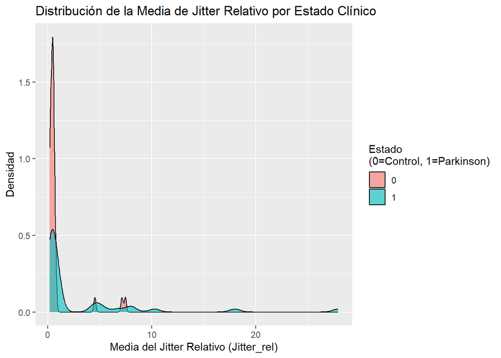

Fig 1. Distribución de la Media de Jitter Relativo por Estado Clínico

Se evaluó la distribución de la media del jitter relativo en los grupos control y Parkinson mediante la **Prueba de Shapiro-Wilk**, observándose desviaciones significativas de la normalidad en ambos grupos p value<0,05.

Con el objetivo de aproximar la normalidad, se aplicó una transformación logarítmica log(1 + x). No obstante, tras la transformación, la variable continuó sin cumplir plenamente el supuesto de normalidad, p-value < 0.05.

```
##
##  Shapiro-Wilk normality test
##
## data:  datos_REL$log_JitterREL[datos_REL$Status == "0"]
## W = 0.53106, p-value = 4.014e-10
```

```
##
##  Shapiro-Wilk normality test
##
## data:  datos_REL$log_JitterREL[datos_REL$Status == "1"]
## W = 0.72231, p-value = 2.307e-07
```

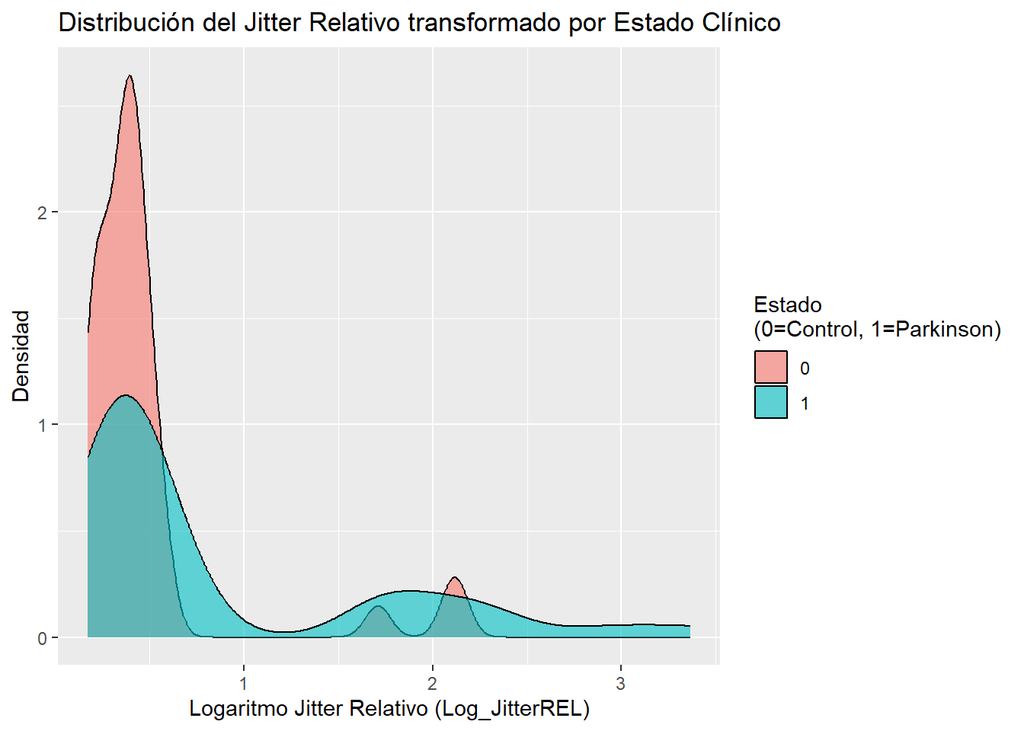

Fig 2. Distribución de Jitter Relativo transformado por Estado Clínico

### 3.3 Análisis Jitter_abs

La media del jitter absoluto fue analizada inicialmente mediante la prueba de **Shapiro–Wilk**, confirmándose la ausencia de normalidad en ambos grupos, p-value < 0.05.

```
##
##  Shapiro-Wilk normality test
##
## data:  datos_ABS$media[datos_ABS$Status == "0"]
## W = 0.89283, p-value = 0.00119
```

```
##
##  Shapiro-Wilk normality test
##
## data:  datos_ABS$media[datos_ABS$Status == "1"]
## W = 0.76182, p-value = 1.187e-06
```

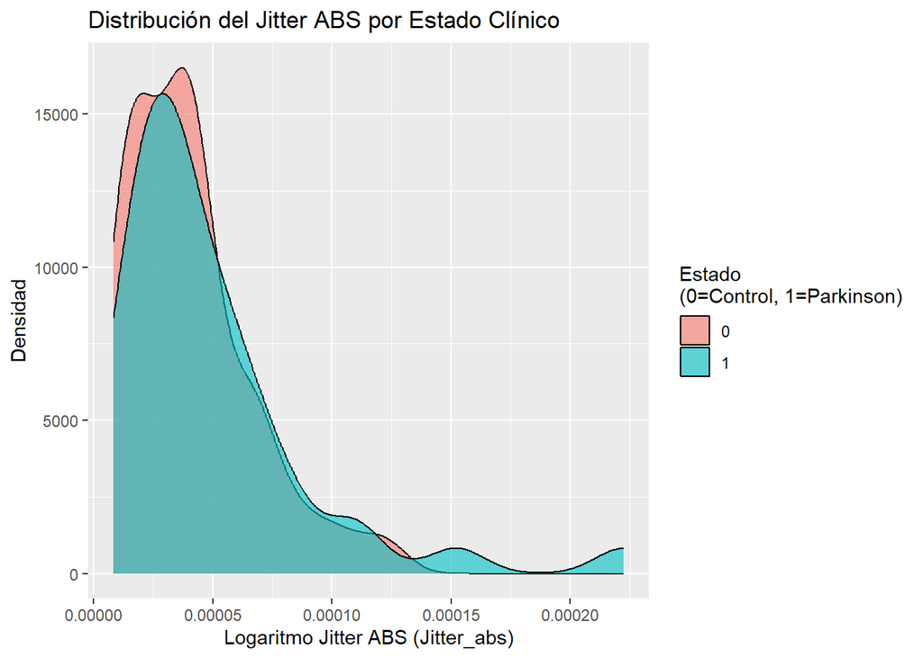

Fig 3. Distribución de la Media de Jitter abs por Estado Clínico

Con el objetivo de aproximar la normalidad, se aplicó una transformación logarítmica log(1 + x). No obstante, tras la transformación, la variable continuó sin cumplir plenamente el supuesto de normalidad, p-value < 0.05.

```
##
##  Shapiro-Wilk normality test
##
## data:  datos_ABS$Log_jitterABS[datos_ABS$Status == "0"]
## W = 0.89284, p-value = 0.001191
```

```
##
##  Shapiro-Wilk normality test
##
## data:  datos_ABS$Log_jitterABS[datos_ABS$Status == "1"]
## W = 0.76184, p-value = 1.188e-06
```

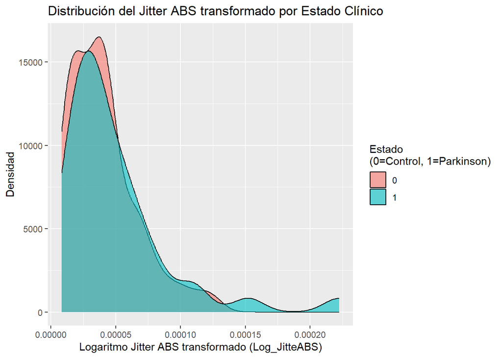

Fig 4. Distribución de Jitter ABS transformado por Estado Clínico

### 3.4 Análisis jitter_RAP

```
##
##  Shapiro-Wilk normality test
##
## data:  datos_RAP$media[datos_RAP$Status == "0"]
## W = 0.83815, p-value = 4.699e-05
```

```
##
##  Shapiro-Wilk normality test
##
## data:  datos_RAP$media[datos_RAP$Status == "1"]
## W = 0.71124, p-value = 1.496e-07
```

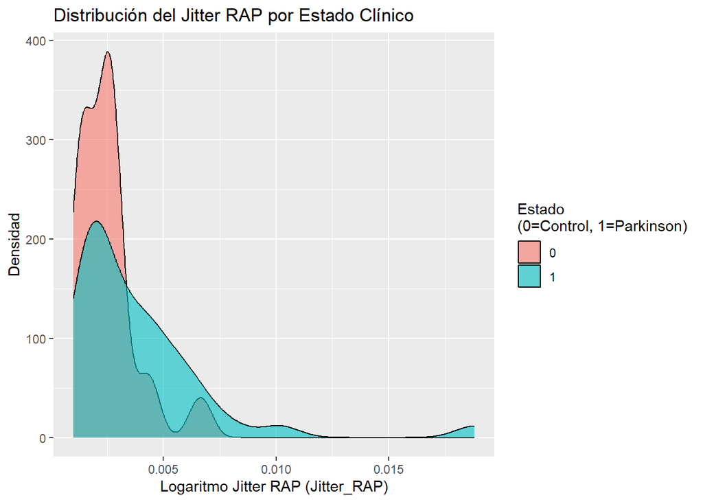

Fig 5. Distribución de la Media de Jitter RAP por Estado Clínico

Se evaluó la distribución de la media del jitter RAP en los grupos control y Parkinson mediante la **Prueba de Shapiro-Wilk**, observándose desviaciones significativas de la normalidad en ambos grupos p value<0,05.

Con el objetivo de aproximar la normalidad, se aplicó una transformación logarítmica log(1 + x). No obstante, tras la transformación, la variable continuó sin cumplir plenamente el supuesto de normalidad,p-value < 0.05.

```
##
##  Shapiro-Wilk normality test
##
## data:  datos_RAP$Log_jitterRAP[datos_RAP$Status == "0"]
## W = 0.83877, p-value = 4.859e-05
```

```
##
##  Shapiro-Wilk normality test
##
## data:  datos_RAP$Log_jitterRAP[datos_RAP$Status == "1"]
## W = 0.71371, p-value = 1.646e-07
```

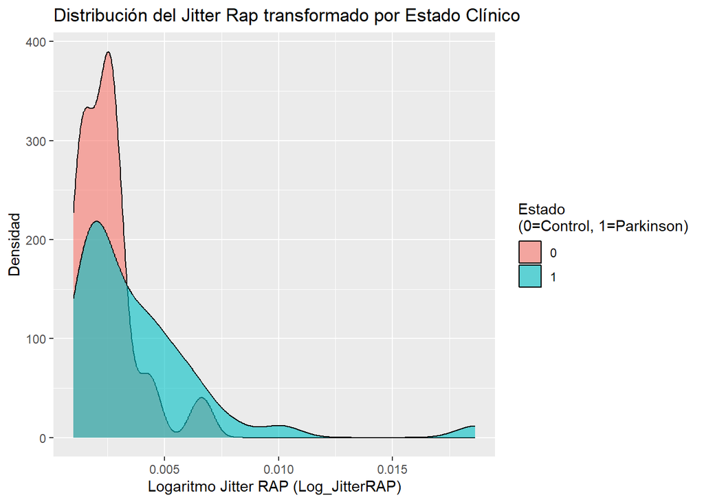

Fig 6. Distribución de Jitter RAP transformado por Estado Clínico

### 3.5 Análisis jitter_PPQ

```
##
##  Shapiro-Wilk normality test
##
## data:  datos_PPQ$media[datos_PPQ$Status == "0"]
## W = 0.88748, p-value = 0.0008429
```

```
##
##  Shapiro-Wilk normality test
##
## data:  datos_PPQ$media[datos_PPQ$Status == "1"]
## W = 0.58106, p-value = 1.741e-09
```

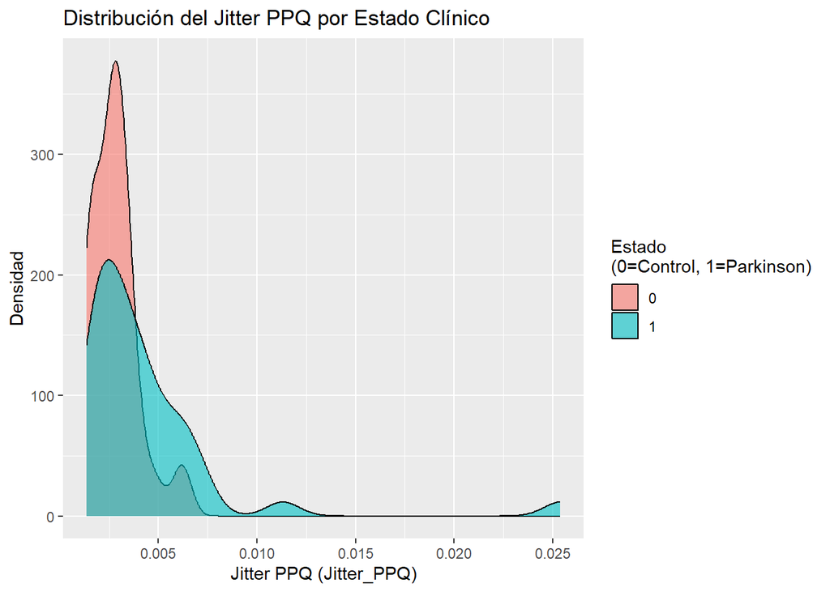

Fig 7. Distribución de la Media de Jitter PPQ por Estado Clínico

Se evaluó la distribución de la media del jitter PPQ en los grupos control y Parkinson mediante la **Prueba de Shapiro-Wilk**, observándose desviaciones significativas de la normalidad en ambos grupos p-value < 0.05.

Con el objetivo de aproximar la normalidad, se aplicó una transformación logarítmica log(1 + x). No obstante, tras la transformación, la variable continuó sin cumplir plenamente el supuesto de normalidad, p-value < 0.05.

```
##
##  Shapiro-Wilk normality test
##
## data:  datos_PPQ$Log_jitterPPQ[datos_PPQ$Status == "0"]
## W = 0.8879, p-value = 0.0008656
```

```
##
##  Shapiro-Wilk normality test
##
## data:  datos_PPQ$Log_jitterPPQ[datos_PPQ$Status == "1"]
## W = 0.58469, p-value = 1.945e-09
```

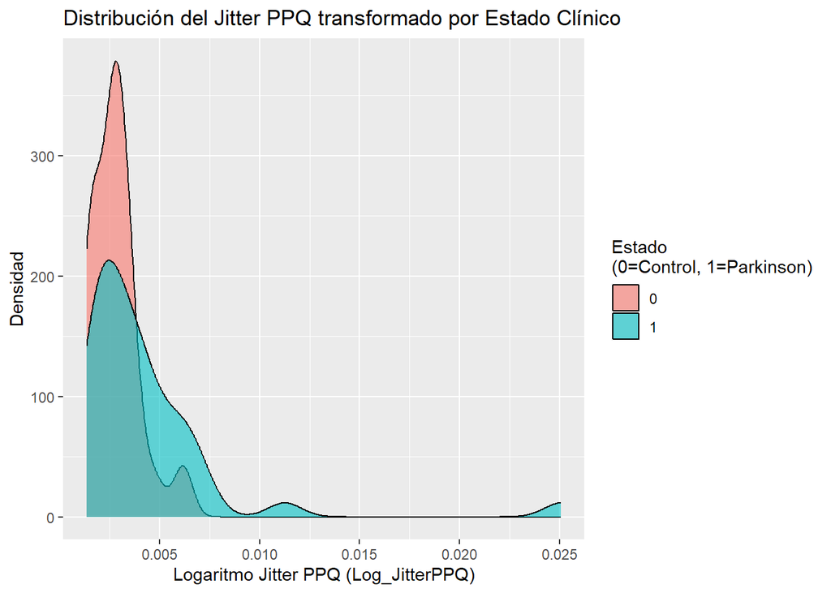

Fig 8. Distribución de Jitter PPQ transformado por Estado Clínico

### 3.6 Análisis de la variable Shimmer

#### Correlación de las variables de Shimmer

Estudiamos la correlación entre las variables de Shimmer para evaluar el grado de relación entre ellas, ayudando a seleccionar aquellas más representativas para el análisis.

```
##            Shim_loc   Shim_dB Shim_APQ3 Shim_APQ5 Shi_APQ11
## Shim_loc  1.0000000 0.7151735 0.9950572 0.9841477 0.9678147
## Shim_dB   0.7151735 1.0000000 0.7160153 0.6973371 0.6855575
## Shim_APQ3 0.9950572 0.7160153 1.0000000 0.9684468 0.9413290
## Shim_APQ5 0.9841477 0.6973371 0.9684468 1.0000000 0.9820101
## Shi_APQ11 0.9678147 0.6855575 0.9413290 0.9820101 1.0000000
```

Matriz de correlación entre las variables de Shimmer

|  | Shim loc | Shim dB | APQ3 | APQ5 | APQ11 |
| --- | --- | --- | --- | --- | --- |
| Shim loc | 1.000 | 0.715 | 0.995 | 0.984 | 0.968 |
| Shim dB | 0.715 | 1.000 | 0.716 | 0.697 | 0.686 |
| APQ3 | 0.995 | 0.716 | 1.000 | 0.968 | 0.941 |
| APQ5 | 0.984 | 0.697 | 0.968 | 1.000 | 0.982 |
| APQ11 | 0.968 | 0.686 | 0.941 | 0.982 | 1.000 |

**Nota:** Los valores corresponden al coeficiente de correlación de Pearson.

#### Preparación del dataset para las variables Shim dB y APQ5

Se seleccionan las variables **Shim db** y **APQ5** y se calculan las medias de cada sujeto, facilitando la comparación entre individuos sanos y con Parkinson

#### 3.6.1 Estudio de la variable Shimmer dB

##### Prueba de normalidad (Shapiro-Wilk)

Usamos el test de Shapiro-Wilk para evaluar la normalidad de la variable Shimmer db dentro de los grupos de individuos sanos y con Parkinson.

```
##
##  Shapiro-Wilk normality test
##
## data:  medias_Shim$Shim_dB_Media[medias_Shim$Status == "0"]
## W = 0.96615, p-value = 0.27
```

```
##
##  Shapiro-Wilk normality test
##
## data:  medias_Shim$Shim_dB_Media[medias_Shim$Status == "1"]
## W = 0.38182, p-value = 8.729e-12
```

##### Comparación entre grupos (Mann-Whitney/Wilcoxon)

Como la distribución entre grupos no es normal, usamos la prueba de suma de rangos de Wilcoxon, o más conocida como la prueba U de Mann-Whitney, que nos permite comparar dos muestras independientes que no cumplen con la normalidad para determinar si existen diferencias significativas entre las medianas de ambas, considerándose una alternativa a la prueba t-student, usada cuando sí existe la normalidad.

```
##
##  Wilcoxon rank sum exact test
##
## data:  Shim_dB_Media by Status
## W = 581, p-value = 0.035
## alternative hypothesis: true location shift is not equal to 0
```

```
##
## Cliff's Delta
##
## delta estimate: -0.27375 (small)
## 95 percent confidence interval:
##       lower       upper
## -0.48548064 -0.03168542
```

#### 3.6.2 Estudio de la variable APQ5

##### Prueba de normalidad (Shapiro-Wilk)

```
##
##  Shapiro-Wilk normality test
##
## data:  medias_Shim$Shim_APQ5_Media[medias_Shim$Status == "0"]
## W = 0.9541, p-value = 0.105
```

```
##
##  Shapiro-Wilk normality test
##
## data:  medias_Shim$Shim_APQ5_Media[medias_Shim$Status == "1"]
## W = 0.79411, p-value = 5.118e-06
```

##### Comparación entre grupos (Mann-Whitney/Wilcoxon)

Como la distribución entre grupos no es normal, usamos la prueba de suma de rangos de Wilcoxon, o más conocida como la prueba U de Mann-Whitney, que nos permite comparar dos muestras independientes que no cumplen con la normalidad para determinar si existen diferencias significativas entre las medianas de ambas, considerándose una alternativa a la prueba t-student, usada cuando sí existe la normalidad.

```
##
##  Wilcoxon rank sum exact test
##
## data:  Shim_APQ5_Media by Status
## W = 576, p-value = 0.03097
## alternative hypothesis: true location shift is not equal to 0
```

```
##
## Cliff's Delta
##
## delta estimate: -0.28 (small)
## 95 percent confidence interval:
##      lower      upper
## -0.4914112 -0.0374275
```

### 3.7 Análisis Univariante de las variables no lineales

Variables No Lineales

| ID | Status | RPDE_Media | PPE_Media | DFA_Media | GNE_Media |
| --- | --- | --- | --- | --- | --- |
| CONT-01 | Healthy | 0.2418028 | 0.0287655 | 0.5937826 | 0.8922816 |
| CONT-02 | Healthy | 0.2447305 | 0.0239397 | 0.5949649 | 0.8751657 |
| CONT-03 | Healthy | 0.2204639 | 0.0422755 | 0.5901909 | 0.9763677 |
| CONT-04 | Healthy | 0.2922599 | 0.7523028 | 0.7581312 | 0.8938280 |
| CONT-05 | Healthy | 0.3228545 | 0.0928155 | 0.7520540 | 0.9338648 |
| CONT-06 | Healthy | 0.3158057 | 0.2584876 | 0.6668312 | 0.9445370 |
| CONT-07 | Healthy | 0.3437744 | 0.4420731 | 0.6173924 | 0.9671196 |
| CONT-08 | Healthy | 0.2881526 | 0.1603942 | 0.5934873 | 0.9097100 |
| CONT-09 | Healthy | 0.3921986 | 0.1048107 | 0.6950959 | 0.8850752 |
| CONT-10 | Healthy | 0.1928563 | 0.0200067 | 0.4978693 | 0.9552758 |

#### 3.7.1 Estudio RPDE

```
##
##  Shapiro-Wilk normality test
##
## data:  DP_Univ$RPDE_Media[DP_Univ$Status == "Healthy"]
## W = 0.97286, p-value = 0.4411
```

```
##
##  Shapiro-Wilk normality test
##
## data:  DP_Univ$RPDE_Media[DP_Univ$Status == "PD"]
## W = 0.97139, p-value = 0.3977
```

```
##
##  Wilcoxon rank sum exact test
##
## data:  RPDE_Media by Status
## W = 731, p-value = 0.5119
## alternative hypothesis: true location shift is not equal to 0
```

```
##
## Cliff's Delta
##
## delta estimate: -0.08625 (negligible)
## 95 percent confidence interval:
##      lower      upper
## -0.3202905  0.1577136
```

#### 3.7.2 Estudio PPE

```
##
##  Shapiro-Wilk normality test
##
## data:  DP_Univ$PPE_Media[DP_Univ$Status == "Healthy"]
## W = 0.90284, p-value = 0.002315
```

```
##
##  Shapiro-Wilk normality test
##
## data:  DP_Univ$PPE_Media[DP_Univ$Status == "PD"]
## W = 0.93342, p-value = 0.02086
```

```
##
##  Wilcoxon rank sum exact test
##
## data:  PPE_Media by Status
## W = 684, p-value = 0.268
## alternative hypothesis: true location shift is not equal to 0
```

```
##
## Cliff's Delta
##
## delta estimate: -0.145 (negligible)
## 95 percent confidence interval:
##      lower      upper
## -0.3858875  0.1143976
```

#### 3.7.3 Estudio DFA

```
##
##  Shapiro-Wilk normality test
##
## data:  DP_Univ$DFA_Media[DP_Univ$Status == "Healthy"]
## W = 0.94921, p-value = 0.07122
```

```
##
##  Shapiro-Wilk normality test
##
## data:  DP_Univ$DFA_Media[DP_Univ$Status == "PD"]
## W = 0.98393, p-value = 0.8303
```

```
##
##  Wilcoxon rank sum exact test
##
## data:  DFA_Media by Status
## W = 767, p-value = 0.7558
## alternative hypothesis: true location shift is not equal to 0
```

```
##
## Cliff's Delta
##
## delta estimate: -0.04125 (negligible)
## 95 percent confidence interval:
##      lower      upper
## -0.2932199  0.2160782
```

### 3.8 Análisis de la variabilidad intra-sujeto

Variabilidad Intra-sujeto (IQR)

| ID | Status | PPE_IQR | RPDE_IQR | DFA_IQR |
| --- | --- | --- | --- | --- |
| CONT-01 | Healthy | 0.0351671 | 0.0339570 | 0.0097584 |
| CONT-02 | Healthy | 0.0149512 | 0.0196454 | 0.0340155 |
| CONT-03 | Healthy | 0.0381027 | 0.0319655 | 0.0230951 |
| CONT-04 | Healthy | 0.0815828 | 0.0027828 | 0.0117133 |
| CONT-05 | Healthy | 0.1228390 | 0.0059774 | 0.0124695 |
| CONT-06 | Healthy | 0.0158469 | 0.0448420 | 0.0290513 |
| CONT-07 | Healthy | 0.0670931 | 0.0206255 | 0.0158011 |
| CONT-08 | Healthy | 0.1250095 | 0.0279138 | 0.0216323 |
| CONT-09 | Healthy | 0.0422961 | 0.0138385 | 0.0156935 |
| CONT-10 | Healthy | 0.0226457 | 0.0083776 | 0.0235105 |

#### 3.8.1 Estudio RPDE

```
##
##  Shapiro-Wilk normality test
##
## data:  DP_var_IQR$RPDE_IQR[DP_var_IQR$Status == "Healthy"]
## W = 0.95896, p-value = 0.1543
```

```
##
##  Shapiro-Wilk normality test
##
## data:  DP_var_IQR$RPDE_IQR[DP_var_IQR$Status == "PD"]
## W = 0.92245, p-value = 0.009205
```

```
##
##  Wilcoxon rank sum exact test
##
## data:  RPDE_IQR by Status
## W = 731, p-value = 0.5119
## alternative hypothesis: true location shift is not equal to 0
```

```
##
## Cliff's Delta
##
## delta estimate: -0.08625 (negligible)
## 95 percent confidence interval:
##      lower      upper
## -0.3276505  0.1657217
```

#### 3.8.2 Estudio PPE

```
##
##  Shapiro-Wilk normality test
##
## data:  DP_var_IQR$PPE_IQR[DP_var_IQR$Status == "Healthy"]
## W = 0.91566, p-value = 0.005638
```

```
##
##  Shapiro-Wilk normality test
##
## data:  DP_var_IQR$PPE_IQR[DP_var_IQR$Status == "PD"]
## W = 0.88345, p-value = 0.0006529
```

```
##
##  Wilcoxon rank sum exact test
##
## data:  PPE_IQR by Status
## W = 849, p-value = 0.6425
## alternative hypothesis: true location shift is not equal to 0
```

```
##
## Cliff's Delta
##
## delta estimate: 0.06125 (negligible)
## 95 percent confidence interval:
##      lower      upper
## -0.1878458  0.3029429
```

#### 3.8.3 Estudio DFA

```
##
##  Shapiro-Wilk normality test
##
## data:  DP_var_IQR$DFA_IQR[DP_var_IQR$Status == "Healthy"]
## W = 0.95659, p-value = 0.1279
```

```
##
##  Shapiro-Wilk normality test
##
## data:  DP_var_IQR$DFA_IQR[DP_var_IQR$Status == "PD"]
## W = 0.90579, p-value = 0.002831
```

```
##
##  Wilcoxon rank sum exact test
##
## data:  DFA_IQR by Status
## W = 811, p-value = 0.92
## alternative hypothesis: true location shift is not equal to 0
```

```
##
## Cliff's Delta
##
## delta estimate: 0.01375 (negligible)
## 95 percent confidence interval:
##      lower      upper
## -0.2290095  0.2548993
```

## Resultados

### 4.1 Resultados jitter

Dado que ninguna de las variables de **jitter** analizadas (jitter relativo, jitter absoluto, jitter RAP y jitter PPQ) cumplió el supuesto de normalidad en ambos grupos, tal como se confirmó mediante la prueba de **Shapiro–Wilk** p-value < 0.05, se empleó la prueba no paramétrica de **Wilcoxon–Mann–Whitney** para comparar los valores entre el grupo control y los pacientes con enfermedad de Parkinson. Esta estrategia permitió evaluar diferencias estadísticas sin asumir normalidad en los datos.

#### 4.1.1 Resultados Jitter_rel

```
##
##  Wilcoxon rank sum exact test
##
## data:  log_JitterREL by Status
## W = 608, p-value = 0.06517
## alternative hypothesis: true location shift is not equal to 0
```

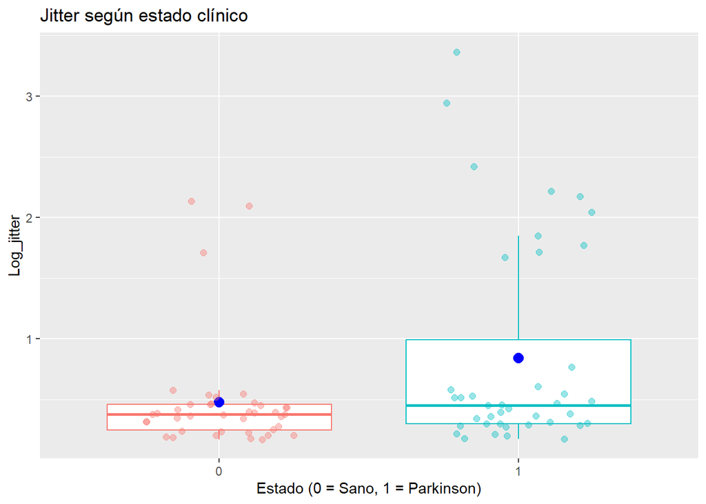

Fig 9. Jitter_rel según el estado clínico

Tras aplicar el wilcox.test en la variable transformada, el valor que obtenemos de **p-value = 0.06517>0.05**. Por tanto, no hay diferencias significativas, NO rechazamos la Hipótesis Nula (H0), la inestabilidad vocal (Jitter_rel) no difiere significativamente entre los pacientes con Parkinson y el grupo de control.

#### 4.1.2 Resultados Jitter_abs

```
##
##  Wilcoxon rank sum exact test
##
## data:  Log_jitterABS by Status
## W = 733, p-value = 0.5243
## alternative hypothesis: true location shift is not equal to 0
```

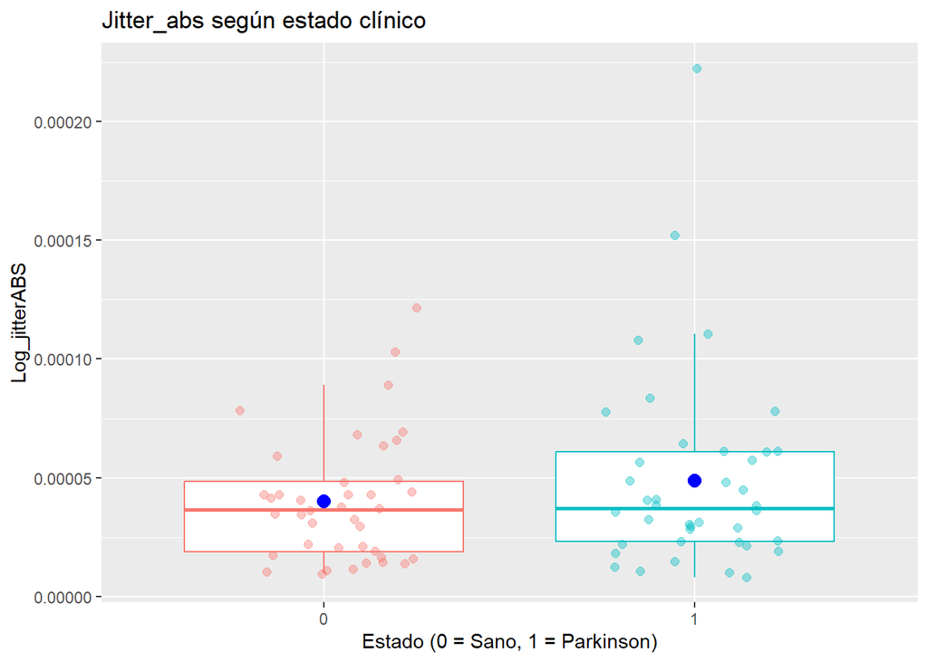

Fig 10. Jitter_abs según el estado clínico

Tras aplicar el wilcox.test en la variable transformada, el valor que obtenemos de **p-value = 0.5243 > 0.05**. Por tanto, no hay diferencias significativas, NO rechazamos la Hipótesis Nula (H0), la inestabilidad vocal (Jitter_abs) no difiere significativamente entre los pacientes con Parkinson y el grupo de control.

#### 4.1.3 Resultados Jitter_RAP

```
##
##  Wilcoxon rank sum exact test
##
## data:  Log_jitterRAP by Status
## W = 580, p-value = 0.03416
## alternative hypothesis: true location shift is not equal to 0
```

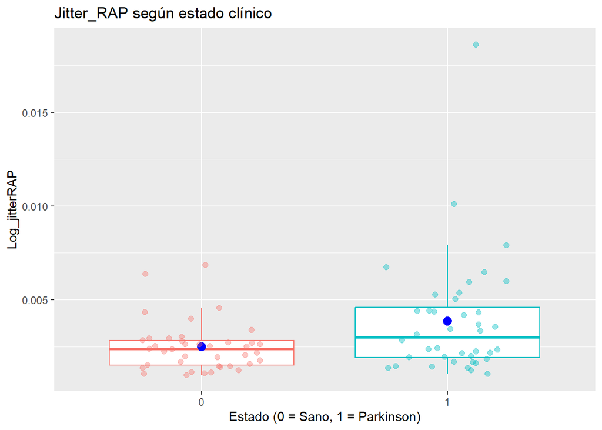

Fig 11. Jitter_RAP según el estado clínico

Tras aplicar el wilcox.test en la variable transformada, el valor que obtenemos de **p-value = 0.03416<0.05**. Por tanto, hay diferencias significativas, aceptamos la Hipótesis alternativa (H1), existe una diferencia significativa en la distribución del Jitter RAP entre el grupo Control y el grupo Parkinson y rechazamos la Hipótesis Nula (H0).

#### 4.1.4 Resultados Jitter_PPQ

```
##
##  Wilcoxon rank sum exact test
##
## data:  Log_jitterPPQ by Status
## W = 575, p-value = 0.03021
## alternative hypothesis: true location shift is not equal to 0
```

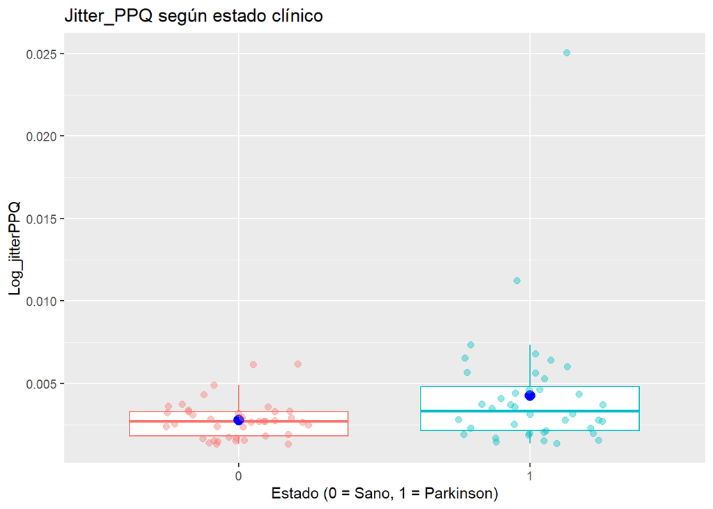

Fig 12. Jitter_PPQ según el estado clínico

Tras aplicar el wilcox.test en la variable transformada, el valor que obtenemos de **p-value = 0.03021<0.05**. Por tanto, hay diferencias significativas, aceptamos la Hipótesis alternativa (H1), existe una diferencia significativa en la distribución del Jitter PPQ entre el grupo Control y el grupo Parkinson y rechazamos la Hipótesis Nula (H0).

### 4.5 Resultados Shimmer dB

La prueba de Shapiro–Wilk indicó que la variable Shim_dB sigue una distribución normal en el grupo sano (p = 0,27), mientras que en el grupo de pacientes con Parkinson no se cumple el supuesto de normalidad (p = 8.729e-12).

Tras aplicar el wilcox.test, los resultados mostraron diferencias significativas entre los grupos de individuos sanos y con Parkinson (p = 0.035), por tanto aceptamos la hipótesis alternativa (H1), la perturbación de la amplitud medida por Shim_dB difiere entre individuos sanos y pacientes con Parkinson, reflejando mayor irregularidad vocal en estos últimos, y rechazamos la hipótesis nula (H0)

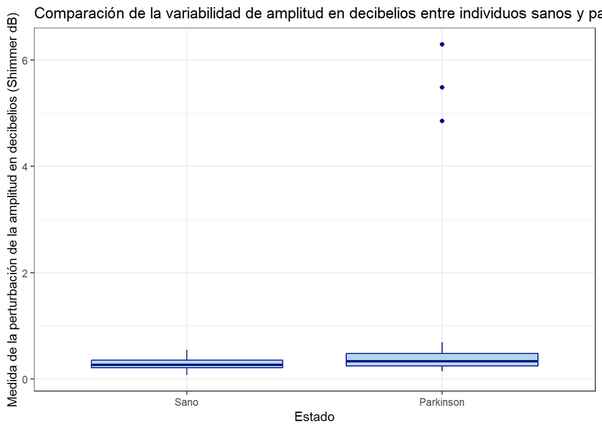

### 4.6 Resultados de APQ5

La prueba de Shapiro–Wilk indicó que la variable APQ5 sigue una distribución normal en el grupo sano (p = 0,105), mientras que en el grupo de pacientes con Parkinson no se cumple el supuesto de normalidad (p = 5.118e-06).

Tras aplicar el wilcox.test, los resultados mostraron diferencias significativas entre los grupos de individuos sanos y con Parkinson (p = 0.03097), por lo que aceptamos la hipótesis alternativa (H1), la perturbación de la amplitud medida por Shim_APQ5 difiere entre individuos sanos y pacientes con Parkinson, reflejando mayor irregularidad vocal en estos últimos, y rechazamos la hipótesis nula (H0)

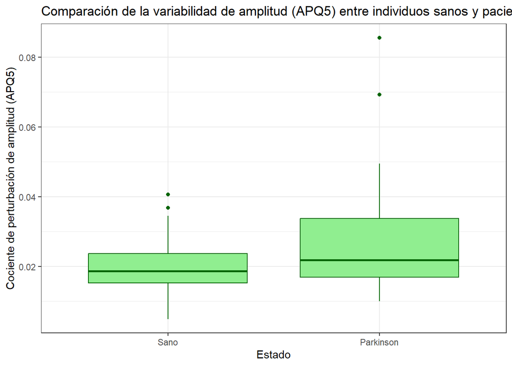

La mediana de APQ5 en pacientes con Parkinson (PD) es superior a la de los individuos sanos, lo que indica que, en promedio, los pacientes presentan mayor irregularidad en la amplitud de la voz. Además, la caja correspondiente a PD es más alta, reflejando una mayor dispersión de los valores y, por lo tanto, una mayor variabilidad vocal. La presencia de algunos valores extremos en el grupo de PD sugiere que ciertos pacientes experimentan alteraciones más pronunciadas, posiblemente asociadas a etapas avanzadas de la enfermedad.

### 4.7 Resultados análisis univariante

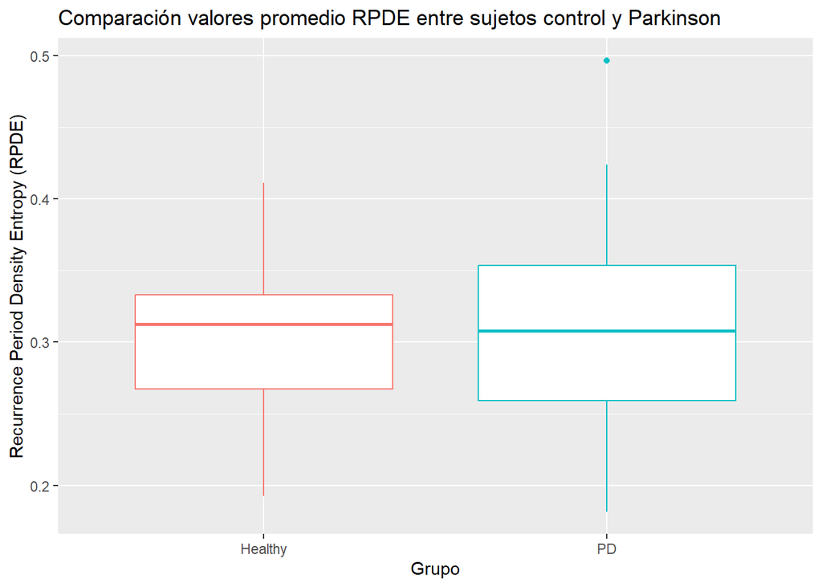

Fig. Boxplot RPDE ~ Status

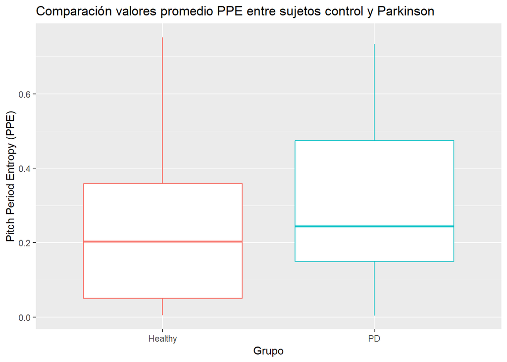

Figura. Boxplot PPE ~ Status

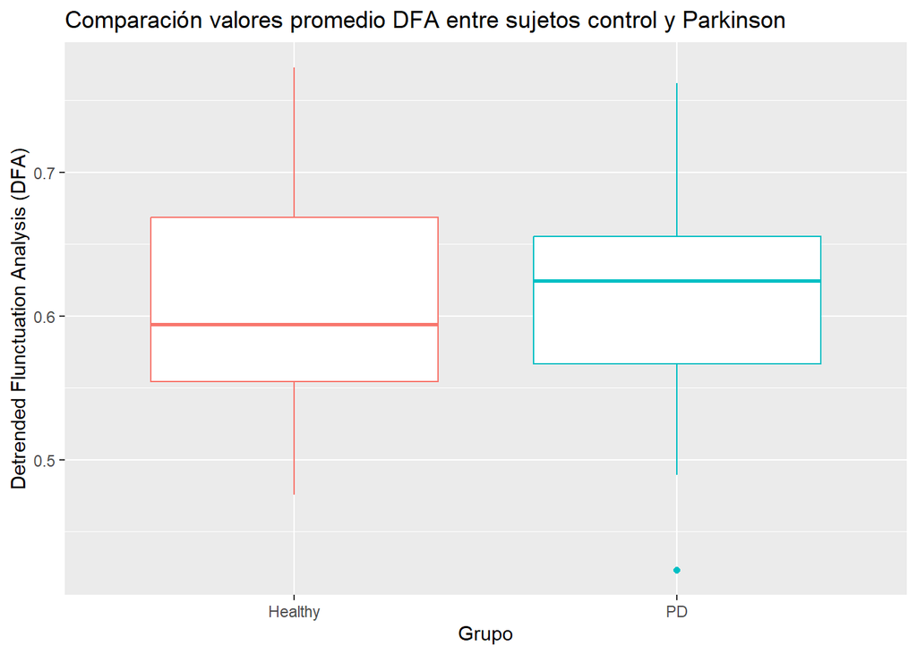

Figura. Boxplot DFA ~ Status

Tras observar los datos visualmente podemos determinar que no existen realmente diferencias significativas entre ambos grupos tomando en cuenta los valores de las variables no lineales, por lo que **NO** rechazaríamos la hipótesis nula **(H0)**. Esto refuerza la idea de que no debemos de tomar estas variables como posibles biomarcadores independientes, sino que cada una nos muestra información complimentaria con la información de las demás.

### 4.8 Resultados análisis variabilidad intra-sujeto

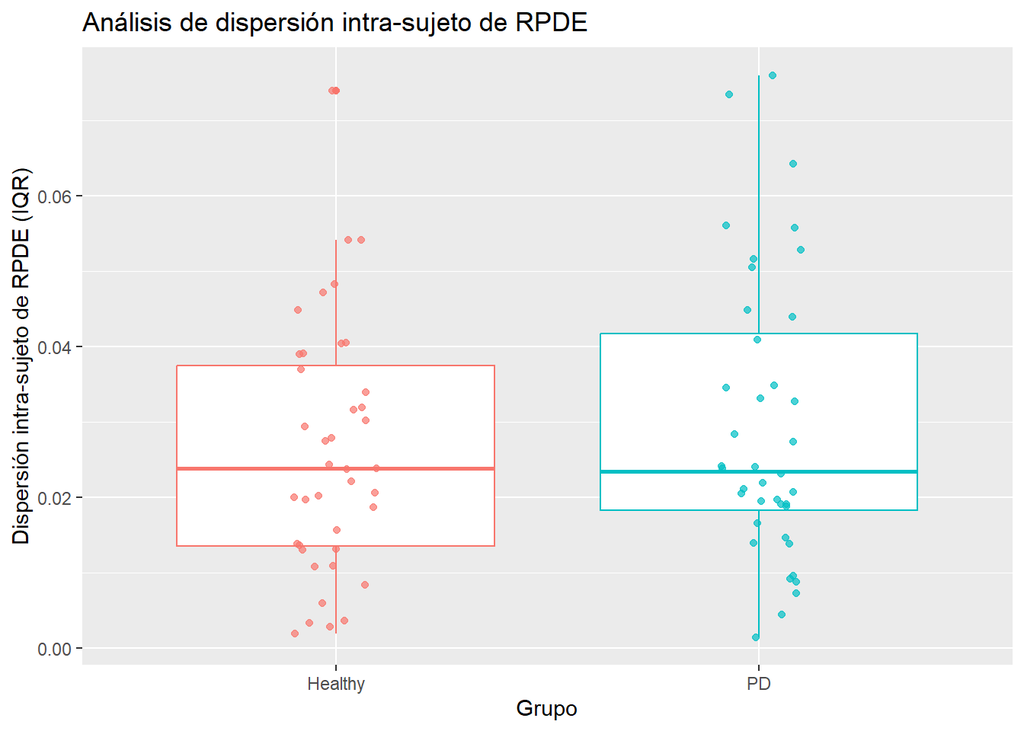

Figura. Boxplot-jitter RPDE ~ Status

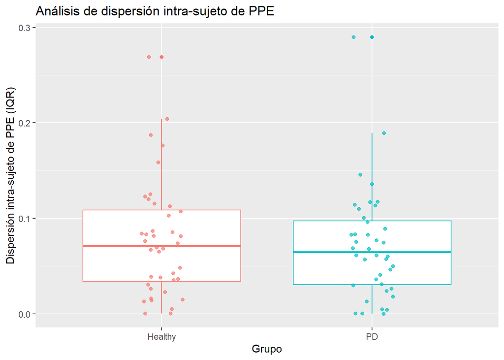

Figura. Boxplot-jitter PPE ~ Status

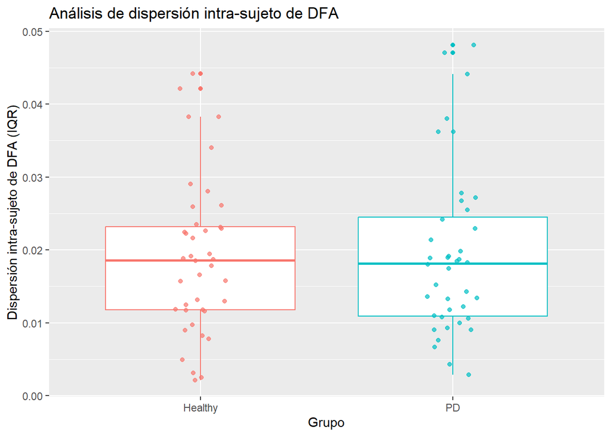

Figura. Boxplot-jitter DFA ~ Status

Tras observar los datos visualmente podemos determinar que no existen realmente diferencias significativas entre los sujetos de ambos grupos, por lo que **NO** rechazaríamos la hipótesis nula **(H0)**. Esto refuerza la idea de que es necesario realizar enfoques que preserven la dinámica temporal o que llegen a integrar múltiples métricas no lineales.

## Conclusiones

En general, esto indica que la selección de métricas sensibles y la consideración de la estructura temporal de la señal son esenciales para desarrollar herramientas de diagnóstico y seguimiento confiables basadas en la voz. Así, la investigación sobre biomarcadores vocales puede contribuir significativamente a la detección temprana y al monitoreo de la enfermedad de Parkinson.

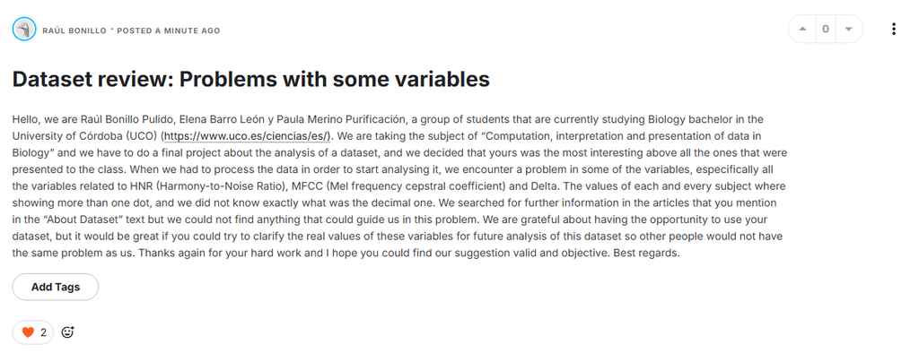

## Información de la sesión y referencias

R Core Team. 2024. *R: A Language and Environment for Statistical Computing*. Vienna, Austria: R Foundation for Statistical Computing. https://www.R-project.org/.

Torchiano, Marco. 2020. *Effsize: Efficient Effect Size Computation*. https://doi.org/10.5281/zenodo.1480624.

Wickham, Hadley, Winston Chang, Lionel Henry, Thomas Lin Pedersen, Kohske Takahashi, Claus Wilke, Kara Woo, Hiroaki Yutani, Dewey Dunnington, and Teun van den Brand. 2024. *Ggplot2: Create Elegant Data Visualisations Using the Grammar of Graphics*. https://ggplot2.tidyverse.org.

Wickham, Hadley, Romain François, Lionel Henry, Kirill Müller, and Davis Vaughan. 2023. *Dplyr: A Grammar of Data Manipulation*. https://dplyr.tidyverse.org.

Wickham, Hadley, Jim Hester, and Jennifer Bryan. 2025. *Readr: Read Rectangular Text Data*. https://doi.org/10.32614/CRAN.package.readr.

Xie, Yihui, Joe Cheng, Xianying Tan, and Garrick Aden-Buie. 2025. *DT: A Wrapper of the JavaScript Library ’DataTables’*. https://doi.org/10.32614/CRAN.package.DT.

Zhu, Hao. 2024. *kableExtra: Construct Complex Table with ’Kable’ and Pipe Syntax*. https://doi.org/10.32614/CRAN.package.kableExtra.

[^1]: Naranjo, L., Perez, C. J., Campos-Roca, Y., & Martin, J. (2016). Addressing voice recording replications for Parkinson’s disease detection. Expert Systems with Applications, 46, 286-292.
[^2]: Naranjo, L., Perez, C. J., Martin, J., & Campos-Roca, Y. (2017). A two-stage variable selection and classification approach for Parkinson’s disease detection by using voice recording replications. Computer methods and programs in biomedicine, 142, 147-156.